# Introducción a las Pruebas de hipótesis

Nicolás Molano Gonzalez

10 agosto, 2025

En este documento introducimos los conceptos básicos al rededor de las pruebas de hipótesis. En resumen las pruebas de hipótesis se usan para probar hipótesis estadísticas acerca de parámetros poblacionales. Veamos un ejemplo

# 1 Estudio metformina + glibenclamida

Un investigador quiere determinar si el tratamiento metformina + glibenclamida funciona, es decir reduce la glucosa en sangre (*glu*) en una población de indígenas del Amazonas. Para esto, con ayuda de un estadístico, se ha diseñado un experimento en donde a una muestra de 100 indígenas de esta población se les hace dos mediciones de *glu*: una primera medición antes de aplicar el medicamento y otra medición después de aplicarlo. Con estos datos de *pre-post*, se calcula la resta de la segunda medición menos la primera. A continuación presentamos como se ven los datos en una tabla:

| Pre | Post | Dif |
| --- | --- | --- |
| 132.7577 | 99.29676 | -33.46092 |
| 144.5275 | 103.71134 | -40.81618 |
| 139.7091 | 97.34189 | -42.36725 |
| 142.6437 | 98.48061 | -44.16305 |
| 142.9979 | 101.95408 | -41.04382 |
| 146.1487 | 103.27149 | -42.87721 |
| 151.1042 | 99.00087 | -52.10329 |
| 148.7323 | 97.64253 | -51.08974 |
| 146.2694 | 95.62619 | -50.64317 |
| 139.4079 | 102.56019 | -36.84773 |

Para estudiar el efecto del medicamento en la *glu* desde un punto de vista estadístico, pensemos en la distribución poblacional de la diferencia *post-pre*, en particular en su valor esperado. Sea $Dif= Post-Pre$. Existen tres posibilidades para $E(Dif)$:

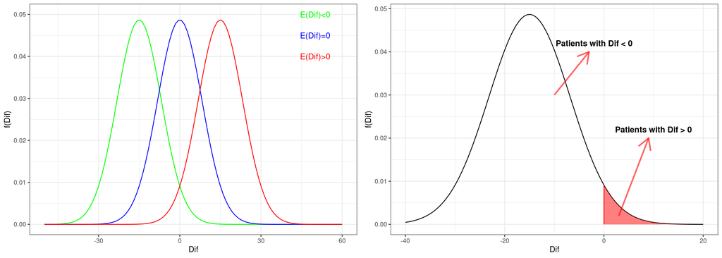

- Si $E(Dif)=0$ esto implicaría que, en general, el tratamiento no cambia los niveles de glucosa en sangre en la población. Esto no quiere decir que los valores de $Dif$ para todos los pacientes sea 0. Lo que ocurriría en la practica es que existen grupos de pacientes para los cuales el medicamento disminuye los niveles de *glu* (es decir $Dif<0$) y para otros aumentaría (es decir $Dif>0$). Parecería que el medicamento funciona aleatoriamente reduciendo o aumentando la *glu* en la población. Ante un comportamiento tan impredecible llegaríamos a la conclusión que el medicamento no funciona.
- Si $E(Dif)<0$ esto implicaría que existe un gran numero de pacientes para los cuales el medicamento produjo una disminución de *glu*. Aunque puedan existir pacientes para los cuales $Dif>0$, es decir que se produjo un aumento de *glu* después de aplicar el tratamiento, este porcentaje de pacientes seria mucho menor que el de aquellos en los que hubo una reducción (es decir $Dif<0$).
- De forma similar sucedería con $E(Dif)>0$

Entonces, es claro que dependiendo del valor de $E(Dif)$ en relación al valor de comparación $0$, se podría concluir acerca de la eficacia del medicamento. Sin embargo, $E(Dif)$ es desconocido y la única forma que tenemos para aproximarnos a su verdadero valor es la información obtenida a partir de la muestra. A continuación presentamos tres muestras obtenidas de las tres posibles distribuciones anteriormente mostradas para $Dif$:

## 1.1 Caso 1

A continuación presentamos una muestra de la población en donde $E(Dif)=0$.

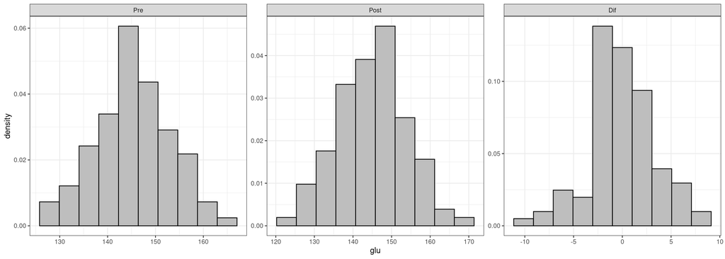

```
##       Pre             Post            Dif
##  Min.   :126.4   Min.   :123.2   Min.   :-10.2411
##  1st Qu.:140.0   1st Qu.:140.0   1st Qu.: -1.9003
##  Median :145.2   Median :145.4   Median : -0.2699
##  Mean   :145.1   Mean   :145.0   Mean   : -0.1101
##  3rd Qu.:150.1   3rd Qu.:150.5   3rd Qu.:  2.1100
##  Max.   :163.5   Max.   :169.2   Max.   :  7.9882
```

Vemos que el valor promedio del *glu* *pre* es 145.12, el valor promedio de *glu* *post* es 145.01 y la diferencia promedio es -0.11. Con estos datos, podríamos pensar que $E(Dif)$ esta muy cerca de 0 y que por ende el medicamento no seria efectivo.

Que herramienta podríamos usar para saber que tan cerca estaría $E(Dif)$ de 0 en base a la información de la muestra? Podríamos calcular el intervalo de 95% de confianza para $E(Dif)$ y ver si el valor de 0 cae en ese intervalo.

Ejercicio: Calcule el intervalo de 95% de confianza para $E(Dif)$ usando la siguiente información: $n=$ 100; $\overline{Dif}=$ -0.11; $S=$ 3.343; usar los cuantiles $t_{99,0.025}=$ -1.984217 y $t_{99,0.975}=$ 1.984217.

Al hacer los cálculos determinamos que el intervalo de confianza es:

```
## [1] -0.7733905  0.5532387
```

Claramente, 0 esta en el intervalo de confianza. Otro dato mas que apoyaría la *hipótesis* de que $E(Dif)=0$.

Otra forma de visualizar los datos e inspeccionar que tanta diferencia hay entre las medidas *pre* y *post* en un boxplot:

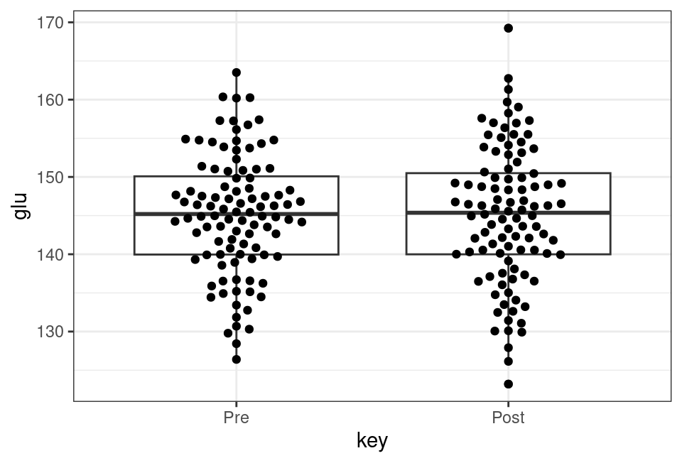

De nuevo vemos evidencia de la nula diferencia entre las medidas *pre* y *post*

## 1.2 Caso 2

Ahora presentamos una muestra de la población en donde $E(Dif)>0$.

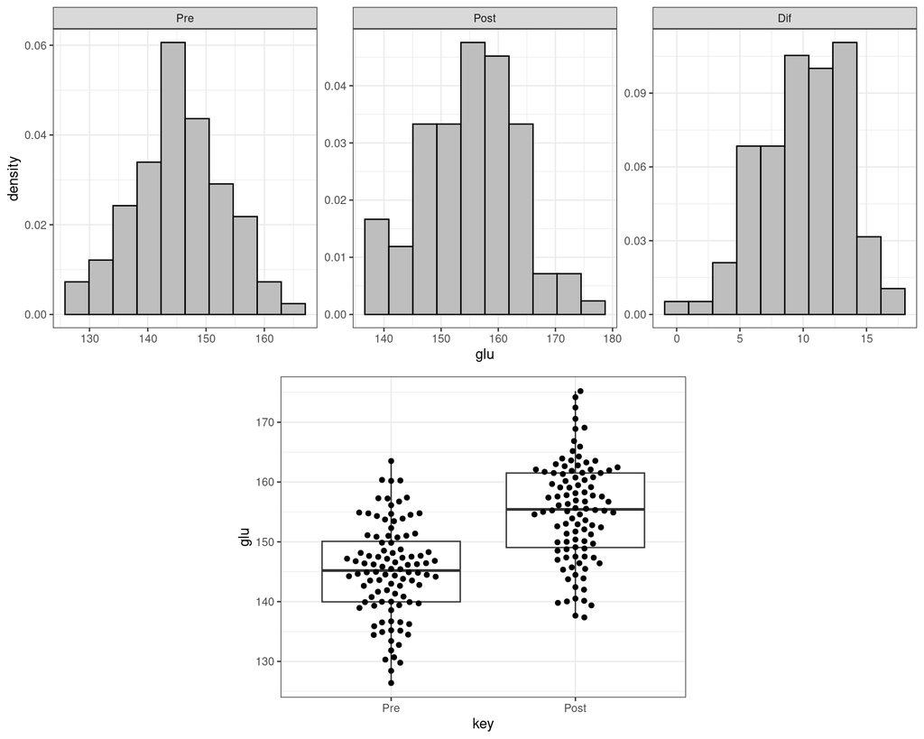

```
##       Pre             Post            Dif
##  Min.   :126.4   Min.   :137.4   Min.   :-0.005429
##  1st Qu.:140.0   1st Qu.:149.0   1st Qu.: 7.453629
##  Median :145.2   Median :155.4   Median :10.380994
##  Mean   :145.1   Mean   :155.1   Mean   : 9.991259
##  3rd Qu.:150.1   3rd Qu.:161.5   3rd Qu.:12.599943
##  Max.   :163.5   Max.   :175.2   Max.   :17.084047
```

Analizando toda la información es claro que el medicamento aumenta la *glu*. Calculemos el intervalo de 95% confianza: $n=$ 100; $\overline{Dif}=$ 9.991; $S=$ 3.441; usamos los cuantiles $t_{99,0.025}=$ -1.984217 y $t_{99,0.975}=$ 1.984217.

Al hacer los cálculos determinamos que el intervalo de confianza es:

```
## [1]  9.308532 10.673985
```

Claramente, el intervalo de confianza esta por encima de 0 y no tendríamos dudas de que el medicamento aumenta la *glu*.

## 1.3 Caso 3

Ahora presentamos una muestra de la población en donde $E(Dif)<0$.

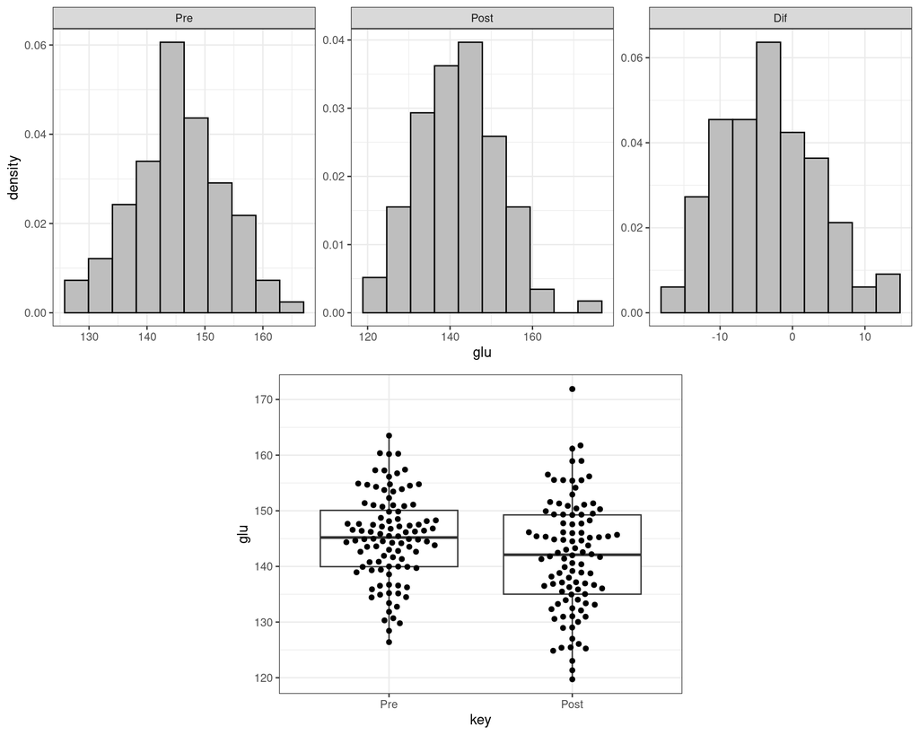

```
##       Pre             Post            Dif
##  Min.   :126.4   Min.   :119.7   Min.   :-15.839
##  1st Qu.:140.0   1st Qu.:135.0   1st Qu.: -8.432
##  Median :145.2   Median :142.1   Median : -4.084
##  Mean   :145.1   Mean   :141.8   Mean   : -3.301
##  3rd Qu.:150.1   3rd Qu.:149.3   3rd Qu.:  1.465
##  Max.   :163.5   Max.   :171.9   Max.   : 13.856
```

Analizando toda la información **no es tan claro** que el medicamento disminuya la *glu*, en particular la disminución es apenas perceptible, la diferencia promedio es de apenas -3.301. Calculemos el intervalo de 95% confianza: $n=$ 100; $\overline{Dif}=$ -3.301; $S=$ 6.672; usamos los cuantiles $t_{99,0.025}=$ -1.984217 y $t_{99,0.975}=$ 1.984217.

Al hacer los cálculos determinamos que el intervalo de confianza es:

```
## [1] -4.624358 -1.976690
```

El intervalo de confianza esta por debajo de 0 indicando que efectivamente $E(Dif)<0$. Sin embargo la evidencia gráfica no nos deja tan convencidos.

# 2 Prueba de hipótesis

Ya que necesitamos una forma objetiva de tomar una decisión frente a la relación que pueda tener $E(Dif)$ con el valor de referencia $0$, desarrollaremos la prueba de hipótesis.

Supongamos que nos interesa demostrar que el medicamento cambia la *glu* sin importar si logra un aumento o disminución. Es decir que nos enteriza demostrar que $E(Dif)\neq 0$. Entonces se plantea el siguiente sistema de hipótesis:
$$H_{0}: E(Dif)=0$$
$$H_{a}: E(Dif) \neq 0$$
$H_0$ y $H_a$ se conocen como hipótesis nula y alternativa respectivamente (mas adelante brindaremos mas detalles acerca de esto).

Ya que estamos hablando acerca del valor esperado, recordemos al estadístico $T$ cuya formula es:
$$T_{n-1}=\frac{\sqrt{n}\Big(\overline{Dif}-E(Dif)\Big)}{S}$$
Donde

- $\overline{Dif}$ es el promedio calculado con la muestra.
- $S$ es la desviación estándar calculada con la muestra.
- $n$ es el tamaño de la muestra y $\sqrt{n}$ su raíz cuadrada.
- $E(Dif)$ es el valor esperado de $Dif$

Y cuya distribución no depende de $E(Dif)$ si no de el tamaño de la muestra $n$.

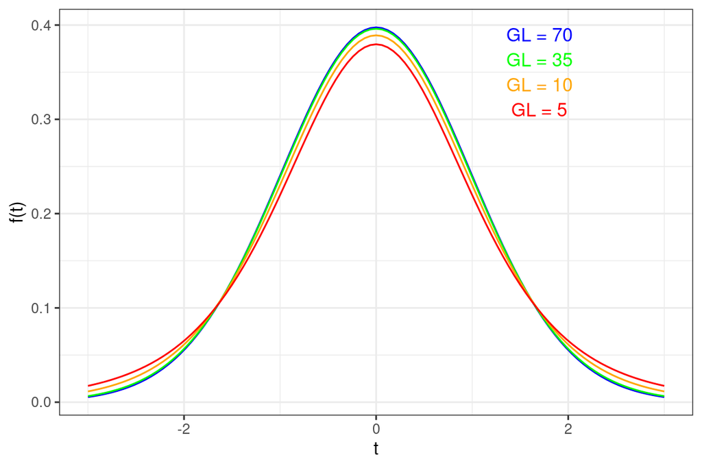

Anteriormente nuca fuimos capases de calcular el estadístico $T$ con los datos de la muestra, ya que en la formula, teníamos toda la información salvo $E(Dif)$, el parámetro poblacional, que precisamente queríamos estimar, y para el cual usamos el estadístico $T$ con el fin de calcular el intervalo de confianza. Sin embargo, si asumimos que la hipótesis nula es cierta entonces $E(Dif)=0$ y tendríamos todos los valores para calcular el estadístico $T$.

A continuación presentamos los valores del estadístico calculados para las tres muestras antes analizadas. (Ejercicio: verifique los cálculos).

|  | Caso | t_obs |
| --- | --- | --- |
| s1 | 1 | -0.3292772 |
| s2 | 2 | 29.0377313 |
| s3 | 3 | -4.9469627 |

La posibilidad de calcular el estadístico $T$ asumiendo el escenario de la hipótesis nula (es decir $E(Dif)=0$) nos permitirá cuantificar que tan probables o compatibles son los datos a la luz de la hipótesis nula. Veamos los estadísticos $t$ calculados en relación con la distribución $T_{99}$:

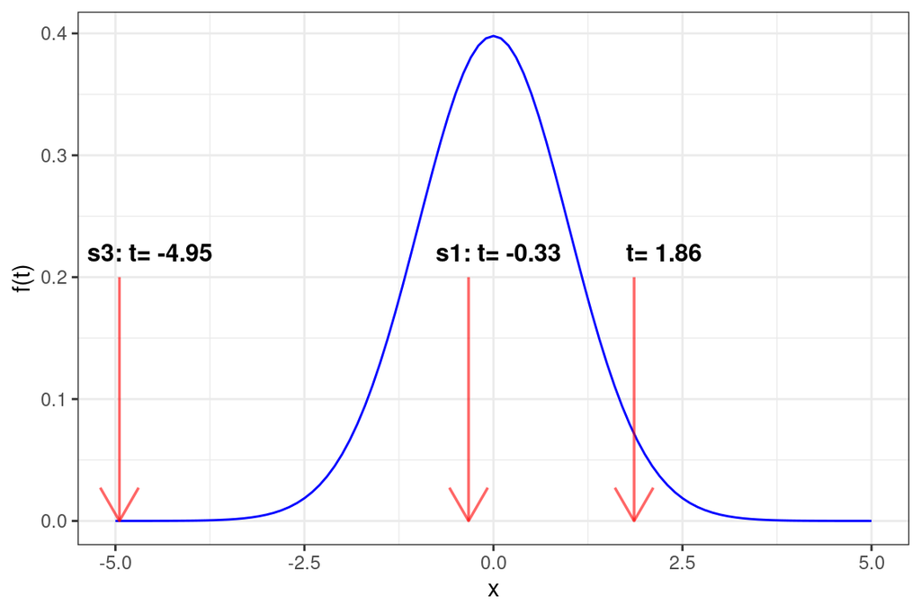

Es claro que el estadístico $t$ calculado con la muestra del **caso 1** (-0.329), se encuentra en una zona de alta densidad de probabilidad bajo la distribución del estadístico $T_{99}$. Esta distribución y el estadístico asumen el escenario de la hipótesis nula (es decir $E(Dif)=0$), por lo cual diremos lo siguiente:

- **Ya que el estadístico $t$ observado, calculado con los datos de la muestra, cayo en una zona de alta densidad de probabilidad, bajo el escenario de la hipótesis nula, concluimos que los datos son altamente compatibles con el escenario de la hipótesis nula**

Es decir, el hecho que el valor del estadístico $t$ observado se encuentre un una zona de alta densidad de probabilidad indicaría que la hipótesis nula $H_{0}: E(Dif)=0$ no podria descartarse.

En contraste el estadístico $t$ calculado con la muestra del **caso 2 y 3** (29.038, -4.947), se encuentran en zonas de muy baja densidad de probabilidad bajo la distribución del estadifico $T_{99}$, por lo cual diremos lo siguiente:

- **Ya que el estadístico $t$ observado, calculado con los datos de la muestra, cayo en una zona de baja densidad de probabilidad, bajo el escenario de la hipótesis nula, concluimos que los datos *NO* son compatibles con el escenario de la hipótesis nula**

Es decir, el hecho que el valor del estadístico $t$ observado se encuentre un una zona de baja densidad de probabilidad indicaría que la hipótesis nula $H_{0}: E(Dif)=0$ **puede descartarse** y la única alternativa restante seria $H_{a}: E(Dif) \neq 0$.

Pero que pensaríamos si el valor del estadístico observado fuera 1.86? abría gente que pensaría que ese valor esta en una región de baja probabilidad pero para otras persona, esa región no tiene una probabilidad despreciable. En esta situación se hace difícil tomar una decisión acerca de la plausibilidad de los datos bajo el escenario de la hipótesis nula.

## 2.1 Limites de Aceptacion y Rechazo

Ya que juzgar si el estadístico de prueba observado (EPO de aque en adelante) se encuentra en una zona de alta o baja probabilidad se hace subjetivo, debemos establecer una regla objetiva para determinar si el EPO se encuentra en una zona de alta o baja probabilidad, es decir, si se acepta o se rechaza la hipótesis nula.

Para esto, de nuevo, usaremos los cuantiles de la distribución $T$. Definiremos dos cuantiles que acumulen una cantidad de probabilidad deseable como $1-\alpha$ (esto se parece a algo!!) y EPOs por fuera de estos dos cuantiles serán considerados como evidencia en contra de la hipótesis nula. Por ejemplo, si $\alpha=0.05$ entonces $1-\alpha=0.95$ y , de nuevo, usaremos los cuantiles $t_{n-1,\alpha/2}$ y $t_{n-1,1-\alpha/2}$

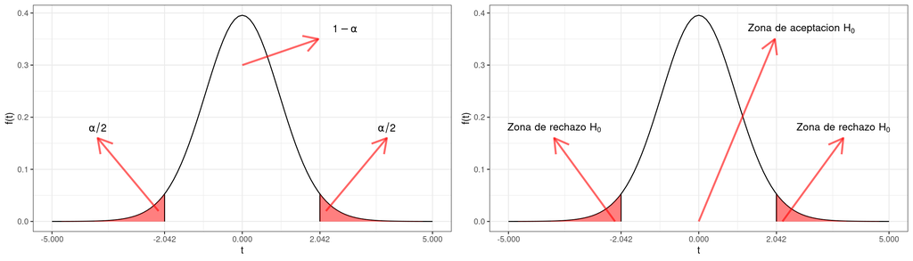

## 2.2 Error tipo I

Una vez establecidos los limites de aceptación y rechazo, debemos caer en cuenta de la posibilidad de equivocarnos en nuestra decisión. Que error podríamos cometer al establecer esta regla de decisión? En primera instancia podríamos rechazar $H_{0}$ cuando esta es en realidad verdadera. Las zonas de baja probabilidad del estadístico $T$ que hemos delimitado con los cauntiles $t_{n-1,\alpha/2}$ y $t_{n-1,1-\alpha/2}$, acumulan en conjunto una probabilidad de $\alpha$, por lo general $\alpha$ es un numero pequeño, al rededor de $0.05$. Esto quiere decir que si $H_0$ es cierta, existe la posibilidad de observar EPO en la zona de rechazo, en concreto la probabilidad de observar esto es de $\alpha=0.05$. De esta forma, y asumiendo que $H_0$ es cierta, con esta regla de decisión la probabilidad de equivocarnos es $\alpha$. El error de rechazar $H_0$ cuando esta es verdadera se llama **Error Tipo I** y $\alpha$ se conoce como **Nivel de significancia** y es en realidad la probabilidad de cometer el error tipo I, claro, en el caso en que $H_0$ es verdadera.
$$\alpha=P_{H_0}(Error~Tipo~I)$$

## 2.3 Vovliendo al ejemplo

Establezcamos los limites de aceptación y rechazo para el caso de nuestro estudio, asumiendo una probabilidad de error tipo I o nivel de significancia $\alpha$ de $0.05$. Debemos encontrar los cuantiles $t_{99,\alpha/2=0.025}$ y $t_{9,1-\alpha/2=0.975}$. Estos tienen los siguientes valores: $t_{99,0.025} =$ -1.984 y $t_{99,0.975} =$ 1.984.

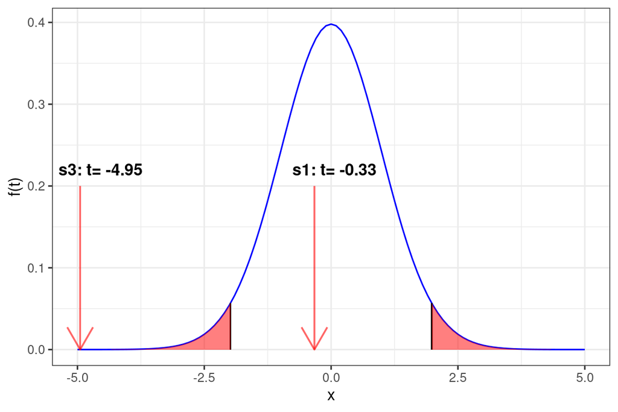

Para las muestras de los casos 2 y 3 el EPO cae en las zonas de rechazo y por ende $H_0: E(Dif)=0$ se rechaza y queda la hipótesis alternativa como única opción $H_a: E(Dif) \neq 0$. Para la muestra del caso 1, el EPO cae en la zona de aceptación y no se puede rechazar $H_0: E(Dif)=0$.

La interpretación de estos resultados, es que al rechazar la hipótesis nula mostramos que, según la información de la muestra, $E(Dif) \neq 0$ y por ende el tratamiento cambia de alguna forma (aun por determinar) la *glu*.

## 2.4 Como plantear sistemas de hipotesis

En el ejemplo anterior, vimos que el sistema de hipótesis empleado fue:

$$H_{0}: E(Dif)= 0$$
$$H_{a}: E(Dif) \neq 0$$

Pero existen 2 sistemas alternativos mas, para un total de 3 posibles sistemas de hipótesis:

| Caso 1 | Caso 2 | Caso 3 |
| --- | --- | --- |
| *H*<sub>0</sub> : *E*(*D**i**f*) = 0 | *H*<sub>0</sub> : *E*(*D**i**f*) ≤ 0 | *H*<sub>0</sub> : *E*(*D**i**f*) ≥ 0 |
| *H*<sub>*a*</sub> : *E*(*D**i**f*) ≠ 0 | *H*<sub>*a*</sub> : *E*(*D**i**f*) > 0 | *H*<sub>*a*</sub> : *E*(*D**i**f*) < 0 |

Las reglas para generar los anteriores sistemas de hipótesis son simples:

- Las hipótesis tratan de parámetros como el $E(X)$ o $V(X)$. Un error común es usar estimadores como $\overline{X}$ en el sistema de hipótesis.
- En la hipótesis nula ($H_0$) siempre debe ir una igualdad o desigualdad

$$=~\leq~\geq$$

- En la hipótesis alternativa ($H_a$) siempre debe ir una desigualdad estricta

$$\neq~<~>$$

- por ultimo debemos escoger un valor de referencia con el cual comparar el parámetro. En este caso el valor de referencia usado es 0

Como escoger cual de los tres sistemas de hipótesis es el adecuado? Eso depende del interés en la investigación. Por ejemplo, si nos interesa demostrar que el medicamento aumenta la *glu*, entonces el sistema de hipótesis apropiado es el numero 2: $H_{0}: E(Dif)\leq 0$ vs $H_{a}: E(Dif) > 0$.

Si nos interesa demostrar que el medicamento disminuye la *glu* entonces el sistema apropiado es el numero 3: $H_{0}: E(Dif)\geq 0$ vs $H_{a}: E(Dif) < 0$.

Si nos interesa mostrar que el medicamento cambia los niveles de *glu*, sin importar si el efecto es de disminución o aumento, entonces el sistema de hipótesis apropiado es el numero 1: $H_{0}: E(Dif)=0$ vs $H_{a}: E(Dif)\neq0$.

Por lo general, y a no ser que se especifique lo contrario, la condición que se quiera demostrar debe ir en la hipótesis alternativa.

## 2.5 Zonas de aceptación y rechazo en función del sistema de hipótesis

En el ejemplo del estudio metformina + glibenclamida discutimos los limites de aceptación y rechazo de la hipótesis nula para el sistema de hipótesis $H_{0}: E(Dif)=0$ vs $H_{a}: E(Dif)\neq0$. Sin embargo, estos limites cambian para los sistemas numero 2 y 3.

Para los efectos de esta discusión, nos concentraremos en pruebas de hipótesis que tratan del valor esperado y la varianza, es decir, los parámetros a probar son $E(X)$ y $V(X)$ para una variable aleatoria $X$ cualquiera.

De esa forma, los tres sistemas de hipótesis disponibles son los siguientes:

| Caso 1 | Caso 2 | Caso 3 |
| --- | --- | --- |
| *H*<sub>0</sub> : *δ* = *c* | *H*<sub>0</sub> : *δ* ≤ *c* | *H*<sub>0</sub> : *δ* ≥ *c* |
| *H*<sub>*a*</sub> : *δ* ≠ *c* | *H*<sub>*a*</sub> : *δ* > *c* | *H*<sub>*a*</sub> : *δ* < *c* |

Donde $\delta$ hace referencia a un parámetro cualquiera ($E(X)$ o $V(X)$) y $c$ es un valor de referencia, como por ejemplo $0$ en el ejemplo anterior.

Para el caso de $E(X)$ el estadístico de prueba que debemos usar es

$$T_{n-1}=\frac{\sqrt{n}\Big(\overline{X}-E(X)\Big)}{S}$$
Como habíamos visto anteriormente, mientras que para $V(X)$ usaremos el estadístico chi cuadrado:

$$\chi_{n-1}^{2}= \frac{(n-1)S^2}{V(X)}$$

Nótese que estos estadísticos son los mismos que usamos en la construcción de intervalos de confianza.

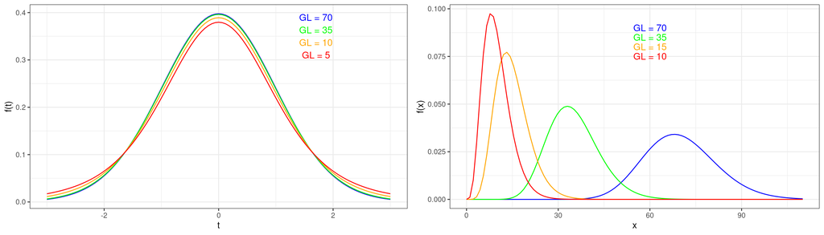

## 2.6 Zona de rechazo para el sistema $H_{0}: \delta=c$ vs $H_{a}: \delta \neq c$

Este caso ya lo conocemos, es el mismo tratado en el ejemplo. Este sistema de hipótesis induce una zona de rechazo compuesta por dos “colas”. Fijado el nivel de significancia $\alpha$ los cuantiles $t_{n-1,\alpha/2}$ y $t_{n-1,1-\alpha/2}$ o los cuantiles $\chi^{2}_{n-1,\alpha/2}$ y $\chi^{2}_{n-1,1-\alpha/2}$ para $E(X)$ y $V(X)$ respectivamente, delimitan las zonas de rechazo como se puede ver a continuación.

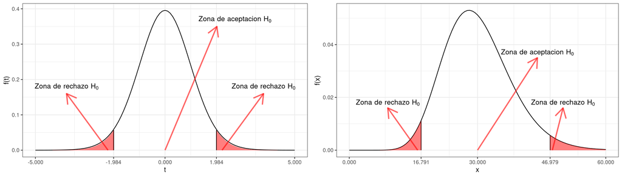

## 2.7 Zona de rechazo para el sistema $H_{0}: \delta \leq c$ vs $H_{a}: \delta > c$

Este sistema de hipótesis induce una zona de rechazo compuesta por una “cola”. Fijado el nivel de significancia $\alpha$ el cuantil $t_{n-1,1-\alpha}$ o $\chi^{2}_{n-1,1-\alpha}$ para $E(X)$ y $V(X)$ respectivamente, delimitan las zonas de rechazo como se puede ver a continuación.

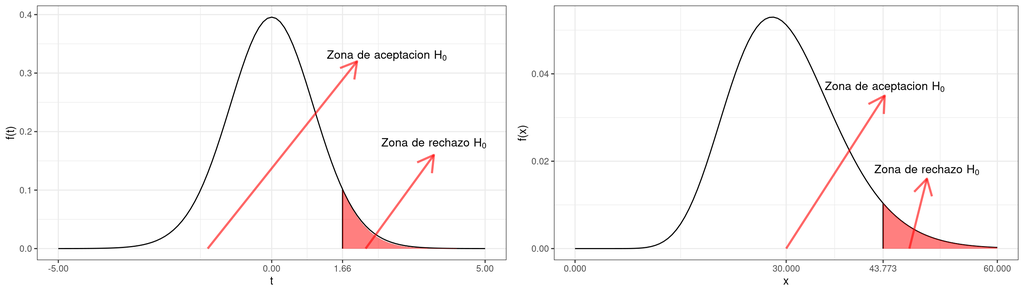

Por que la zona de rechazo se encuentra a la derecha, en valores grandes de los estadísticos de prueba? La respuesta yace en las formulas de los estadísticos de prueba $T_{n-1}$ y $\chi_{n-1}^{2}$ y por supuesto en la hipótesis alternativa $H_{a}: \delta > c$. En ambas formulas de los estadísticos de prueba, valores de $E(X)$ 0 $V(X)$ mayores a $c$ se asocian con valores de los estadísticos de prueba grandes (es decir situados a la derecha) en la distribución de estos.

## 2.8 Zona de rechazo para el sistema $H_{0}: \delta \geq c$ vs $H_{a}: \delta < c$

Este sistema de hipótesis induce una zona de rechazo compuesta por una “cola”. Fijado el nivel de significancia $\alpha$ el cuantil $t_{n-1,\alpha}$ o $\chi^{2}_{n-1,\alpha}$ para $E(X)$ y $V(X)$ respectivamente, delimitan las zonas de rechazo como se puede ver a continuación.

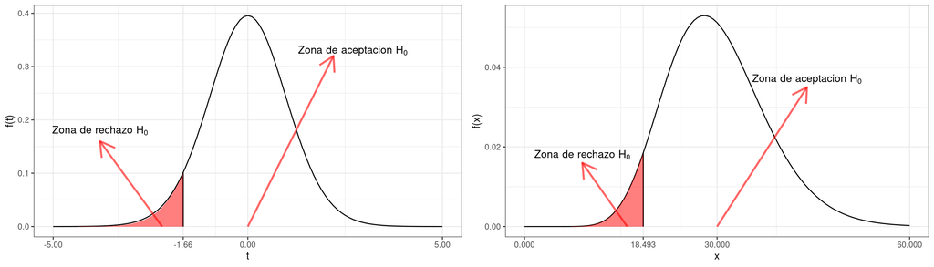

# 3 Resumen

A continuación resumimos los pasos necesarios que se deben ejecutar para realizar una prueba de hipótesis.

1. Determine el parámetro sobre el cual se desea hacer la prueba de hipótesis (en nuestro caso nos limitaremos a trabajar con $E(X)$ o $V(X)$).
2. Escoja el sistema de hipótesis apropiado de acuerdo al problema de interés:

   | Caso 1 | Caso 2 | Caso 3 |
   | --- | --- | --- |
   | *H*<sub>0</sub> : *δ* = *c* | *H*<sub>0</sub> : *δ* ≤ *c* | *H*<sub>0</sub> : *δ* ≥ *c* |
   | *H*<sub>*a*</sub> : *δ* ≠ *c* | *H*<sub>*a*</sub> : *δ* > *c* | *H*<sub>*a*</sub> : *δ* < *c* |

   Donde $\delta$ hace referencia a un parámetro cualquiera ($E(X)$ o $V(X)$) y $c$ es un valor de referencia.
3. Fije el nivel de significancia $\alpha$.
4. Dependiendo de el parámetro escogido en el paso 1, use el estadístico de prueba apropiado:

$$para~E(X):~T_{n-1}=\frac{\sqrt{n}\Big(\overline{X}-E(X)\Big)}{S}~~~o~~~para~V(X):~\chi_{n-1}^{2}= \frac{(n-1)S^2}{V(X)}$$

5. Dependiendo del sistema de hipótesis escogido en el paso dos y el nivel de significancia $\alpha$ fijado en el paso 3, determine las zonas de aceptación y rechazo usando los cuantiles apropiados.
6. Dependiendo del estadístico seleccionado en el paso 4, calcule el estadístico de prueba observado EPO con los datos de la muestra. Recuerde que para esto se debe reemplazar el parámetro con el valor de comparación:

$$EPO~para~E(X):~\frac{\sqrt{n}\Big(\overline{x}-c\Big)}{S}~~~o~~~EPO~para~V(X):~\frac{(n-1)s^2}{c}$$

7. Determine si el EPO calculado en el paso anterior cae o no en la zona de rechazo, para finalmente determinar si $H_0$ se puede o no rechazar.

# 4 Ejemplos

A continuación presentaremos algunos ejemplos ilustrando el proceso de las pruebas de hipótesis.

## 4.1 Ejemplo 1

Un agricultor tiene un gallinero con 5000 gallinas. El afirma que para tener ganancias vendiéndolas como carne, las gallinas deben tener un valor esperado de peso mayor a $300g$. Con el fin de Probar si su población de gallinas cumple con este requerimiento, a extraído una muestra de 71 gallinas y las ha pesado. A continuación presentamos el histograma de estos datos:

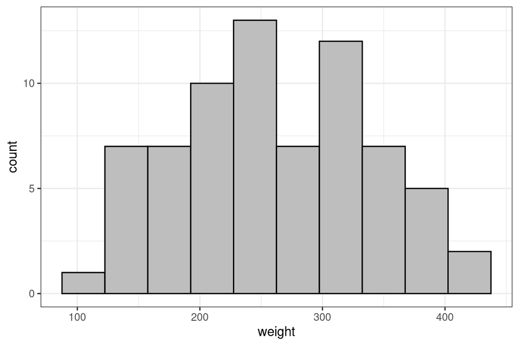

y presentamos algunas estadísticas descriptivas de estos datos:

```
##    Min. 1st Qu.  Median    Mean 3rd Qu.    Max.
##   108.0   204.5   258.0   261.3   323.5   423.0
```

- El promedio de esta muestra es $\overline{X}=$ 261.31
- La varianza estimada de esta muestra es $S^2=$ 6095.503

Para esto usted dispone de la siguiente información:

1. Plantee el sistema de hipótesis apropiado para este problema.
2. Si se fija un nivel de significancia $\alpha=0.05$, haga la prueba de hipótesis y concluya si el agricultor obtendrá ganancias con sus gallinas.
3. algunos cuantiles de la distribución $T$

| GL | qT_0.005 | qT_0.025 | qT_0.05 | qT_0.1 | qT_0.9 | qT_0.95 | qT_0.975 | qT_0.995 |
| --- | --- | --- | --- | --- | --- | --- | --- | --- |
| 35 | -2.7238 | -2.0301 | -1.6896 | -1.3062 | 1.3062 | 1.6896 | 2.0301 | 2.7238 |
| 50 | -2.6778 | -2.0086 | -1.6759 | -1.2987 | 1.2987 | 1.6759 | 2.0086 | 2.6778 |
| 69 | -2.6490 | -1.9949 | -1.6672 | -1.2939 | 1.2939 | 1.6672 | 1.9949 | 2.6490 |
| 70 | -2.6479 | -1.9944 | -1.6669 | -1.2938 | 1.2938 | 1.6669 | 1.9944 | 2.6479 |
| 71 | -2.6469 | -1.9939 | -1.6666 | -1.2936 | 1.2936 | 1.6666 | 1.9939 | 2.6469 |
| 80 | -2.6387 | -1.9901 | -1.6641 | -1.2922 | 1.2922 | 1.6641 | 1.9901 | 2.6387 |
| 100 | -2.6259 | -1.9840 | -1.6602 | -1.2901 | 1.2901 | 1.6602 | 1.9840 | 2.6259 |

4. algunos cuantiles de la distribución $\chi^2$

| GL | qChi_0.005 | qChi_0.025 | qChi_0.05 | qChi_0.1 | qChi_0.9 | qChi_0.95 | qChi_0.975 | qChi_0.995 |
| --- | --- | --- | --- | --- | --- | --- | --- | --- |
| 35 | 17.1918 | 20.5694 | 22.4650 | 24.7967 | 46.0588 | 49.8018 | 53.2033 | 60.2748 |
| 50 | 27.9907 | 32.3574 | 34.7643 | 37.6886 | 63.1671 | 67.5048 | 71.4202 | 79.4900 |
| 69 | 42.4935 | 47.9242 | 50.8792 | 54.4381 | 84.4179 | 89.3912 | 93.8565 | 102.9962 |
| 70 | 43.2752 | 48.7576 | 51.7393 | 55.3289 | 85.5270 | 90.5312 | 95.0232 | 104.2149 |
| 71 | 44.0584 | 49.5922 | 52.6003 | 56.2206 | 86.6354 | 91.6702 | 96.1887 | 105.4320 |
| 80 | 51.1719 | 57.1532 | 60.3915 | 64.2778 | 96.5782 | 101.8795 | 106.6286 | 116.3211 |
| 100 | 67.3276 | 74.2219 | 77.9295 | 82.3581 | 118.4980 | 124.3421 | 129.5612 | 140.1695 |

### 4.1.1 Solución:

1. Del problema se identifica que el parámetro que se desea evaluar es $E(Peso)$ es decir el valor esperado del peso de las gallinas.
2. Ya que se desea demostrar que $E(Peso) > 300g$ el sistema de hipótesis apropiado es
   $$H_0: E(Peso)\leq 300$$
   $$H_0: E(Peso)> 300$$
3. Para el valor esperado se debe usar el estadístico $T$.
4. La zona de rechazo para este sistema de hipótesis es a una cola, a la derecha, por lo que el cuantil que delimita la zona de rechazo es $t_{n-1,1-\alpha}$, donde $n=71$, $1-\alpha=0.95$, es decir el cuantil $t_{70,0.95}$. De la tabla se puede observar que el valor de este cuantil es 1.6669
5. Con la información suministrada calculamos el estadístico de prueba:

$$\frac{\sqrt{n}\Big(\overline{x}-c\Big)}{S}=\frac{\sqrt{71}\Big(261.31-300\Big)}{\sqrt{6095.503}}=-4.176$$
6. Al comparar el EPO con el cuantil $t_{70,0.95}= 1.6669$ observamos que el EPO cae en la zona de aceptación de $H_0$ por lo cual la hipótesis nula no se puede rechazar.

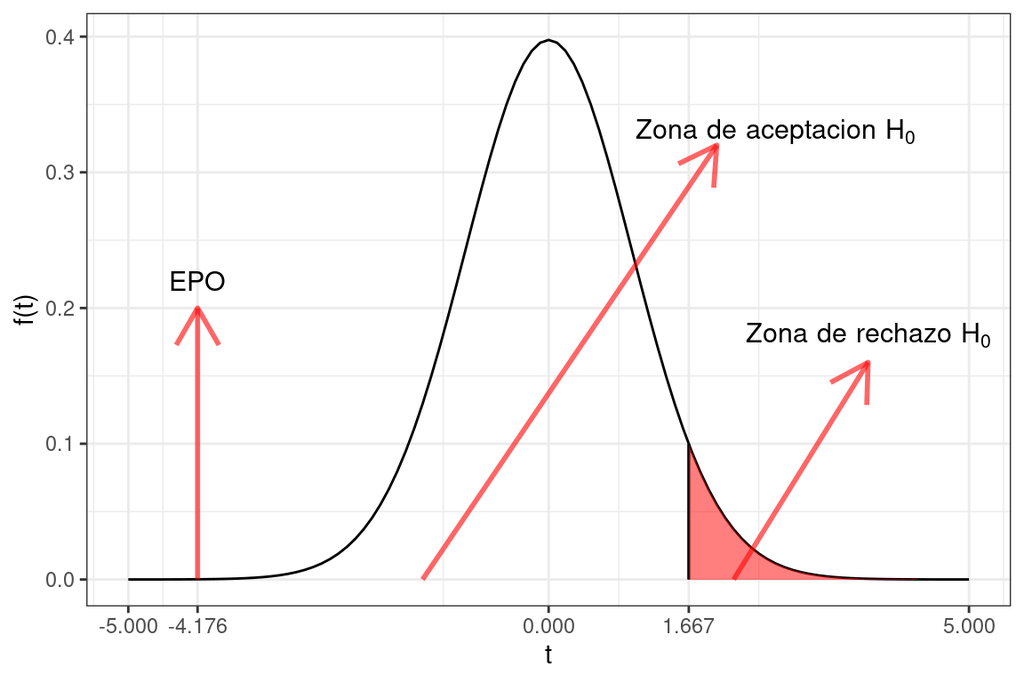

7. Conclusión: el agricultor no obtendrá ganancia.

# 5 P-valor

Hasta ahora hemos visto que para determinar si la hipotesis nula se rechaza o no en base a unos datos, debemos delimitar la zona de rechaso, calcular el EPO y verificar en donde se encuentra en relacion a la zona de rechazo. A continuacion presentarmos otra criterio para de determinar si se rechaza o no la hipotesis nula, el cual se basa en el uso del *p-valor*.

Por simplicidad asumamos que el sistema de hipotesis que se estudiara es de la forma
$$H_{0}: \delta \leq c~~ vs~~ H_{a}: \delta > c$$
Recordemos que la zona de rechazo, para un nivel de significancia dado, tiene la siguiente forma:

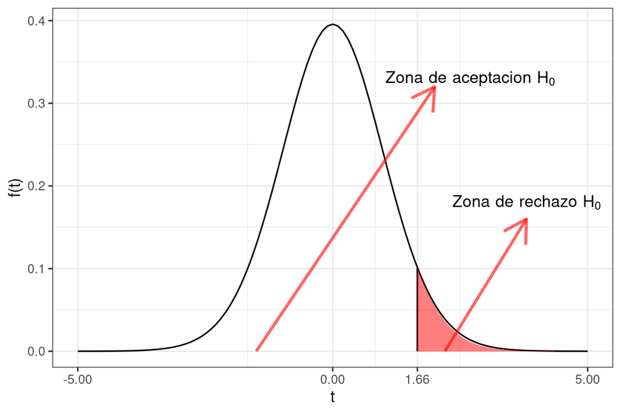

En este caso el numero 1.66 seria el cuantil $1-\alpha$ para algun $\alpha$ en particular. En este contexto, el *p-valor* se define como

- “La probabilidad, bajo la funcion de densidad del estadistico de prueba que asume que la hipotesis nula es cierta, de observar valores mayores al EPO”.

Por ejemplo si el estadstico de prueba es la $T_{n-1}$ el *p-valor* se define como:

$$p-valor=P(T_{n-1}>EPO)$$
Vamos un ejemplo. Suponga que $EPO= 1.5$ entonces:

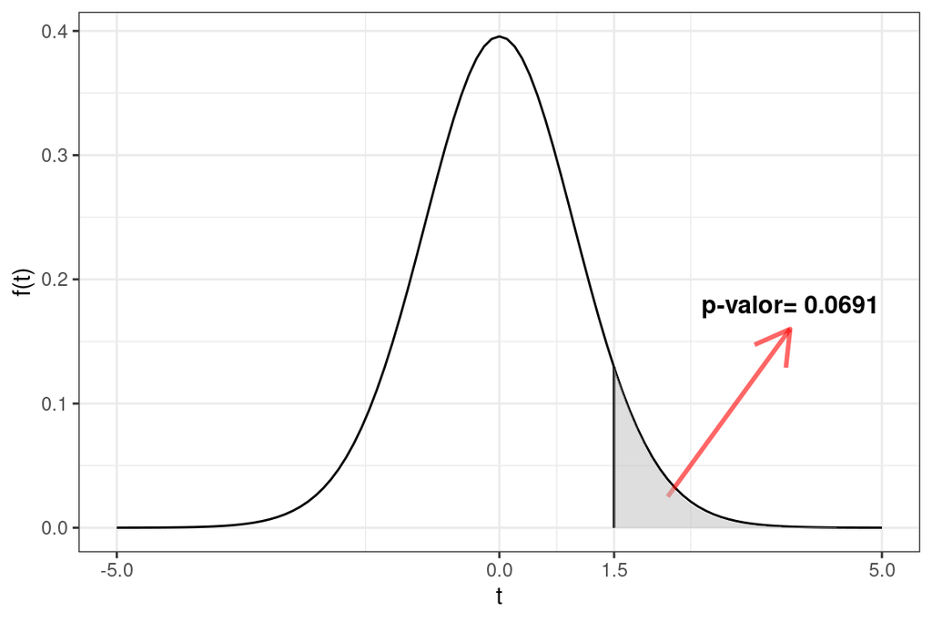

El p-valor puede ser usado para determinar si la hipotesis nula se rechaza o no con base a la siguiente regla:

- Si $p-valor < \alpha$ entonces La hipotesis nula es rechazada.

Esto se debe a que si el $p-valor < \alpha$ eso quiere decir que el EPO ha caido en la zona de rechazo, de lo contrario, el EPO se encuentra en la zona de aceptacion, tal y como se puede observar en la siguiente figura:

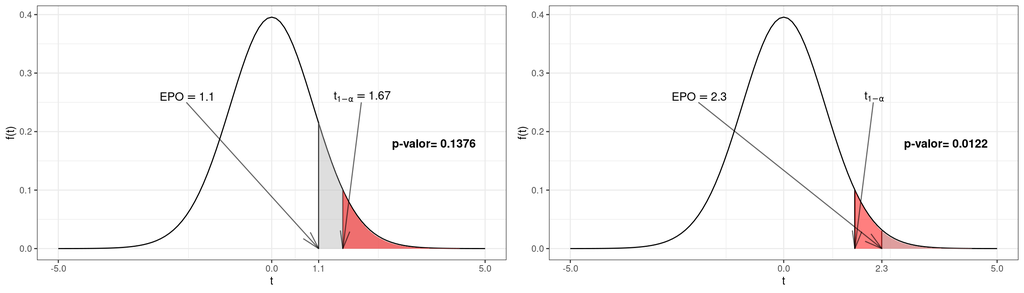

# 6 Notas finales

De manera similar al calculo de los intervalos de confianza, vemos que es necesario determinar los cuantiles de las distribuciones $T$ de student, $\chi^2$ y la distribución normal estándar en el cálculo de las pruebas de hipótesis. Estos cuantiles pueden ser calculados en R usando las funciones `qt(), qchisq()`. Invitamos a los lectores a consultar el uso y funcionamiento de estas funciones en R

`?qt`  
`?qchisq`

Por otra parte, es importante discutir algunos supuestos que existen entorno a los cálculos dde las pruebas de hipótesis para el valor esperado y la varianza. Como se vio anteriormente, en su derivación aparecieron los estadísticos $T_{n-1}$ y $\chi^2_{n-1}$ y gracias a que estos estadísticos poseen una distribución conocida, fue posible derivar las formulas de las pruebas de hipótesis. Sin embargo, las distribuciones de estos estadísticos son las descritas, si y solamente si, la variable aleatoria original, objeto de estudio, posee una distribución normal. Esto se conoce como el supuesto de normalidad.

Esto quiere decir que, las pruebas de hipótesis calculadas, en particular la decisión de aceptar o rechazar la hipótesis nula, es correcta si y solamente si la variable original, a nivel población también posee una distribución normal. Algunos estudios han demostrado que, cuando la variable no posee una distribución normal, los errores incurridos en la decisión tomada en la prueba de hipótesis pueden ser mínimos en algunos casos. Mas adelante veremos algunas formas de evaluar si la distribución de una variable puede ser considerada como normal o no usando los datos de la muestra.